# Этап индивидуального проекта №3

Операционные системы

Куокконен Дарина Андреевна, НКАбд-03-23

Российский университет дружбы народов, Москва, Россия

## Цель работы

Продолжить работу с сайтом, теперь нужно добавить личную информацию, пару постов.

## Задание

1. Добавить информацию о навыках (Skills).
2. Добавить информацию об опыте (Experience).
3. Добавить информацию о достижениях (Accomplishments).
4. Сделать пост по прошедшей неделе.
5. Добавить пост на тему по выбору.

## Выполнение проекта

Захожу в терминал, перехожу в директорию ~/work/blog, ввожу команду ~/bin/hugo server для запуска локального сервера

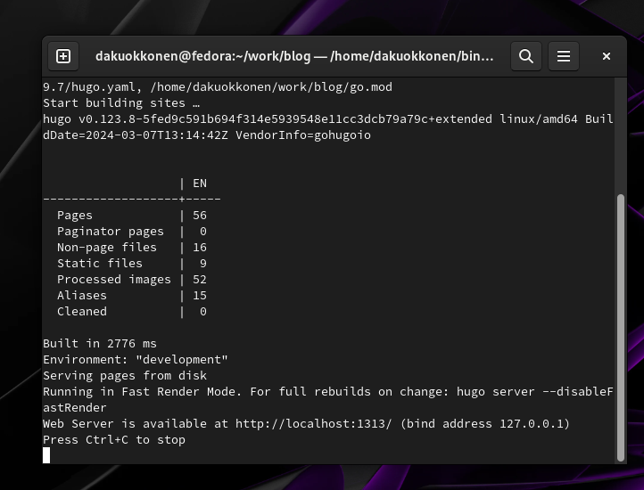

Запуск локального сервера

## Выполнение проекта

- Перехожу в директорию ~/work/blog/content/authors/admin
- Открываю файл _index.md, его я буду редактировать далее
- В разделе “Skills” прописываю свои навыки
- Иконки поставила, найдя в интернете официальную библиотеку fas

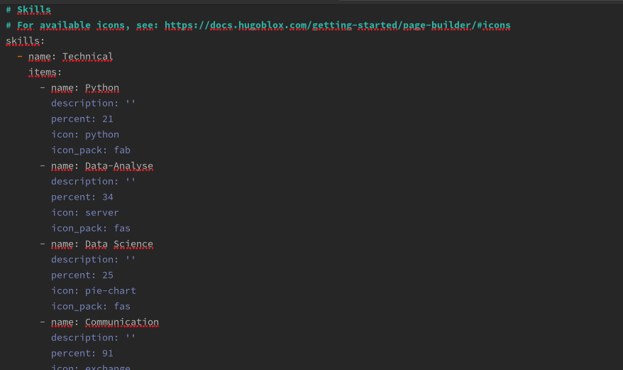

Добавление навыков

## Выполнение проекта

Изменяю раздел с моими увлечениями (рис. 3)

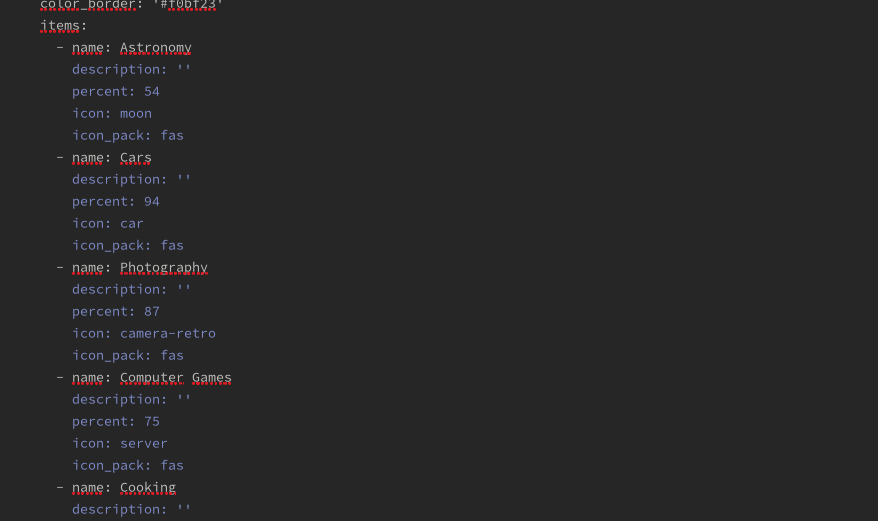

Добавление интересов

## Выполнение проекта

Проверяю, есть ли изменения на сайте (рис. 4)

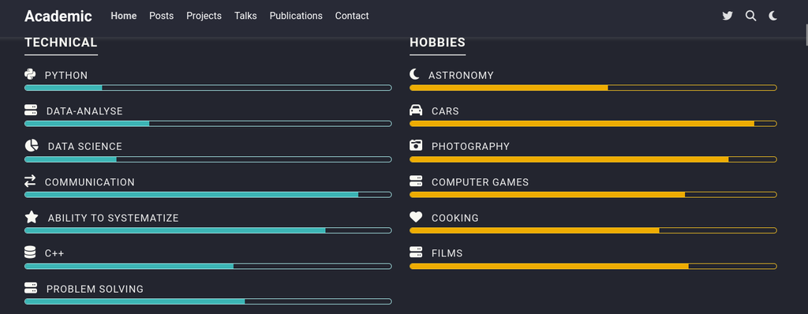

Проверка изменений

## Выполнение проекта

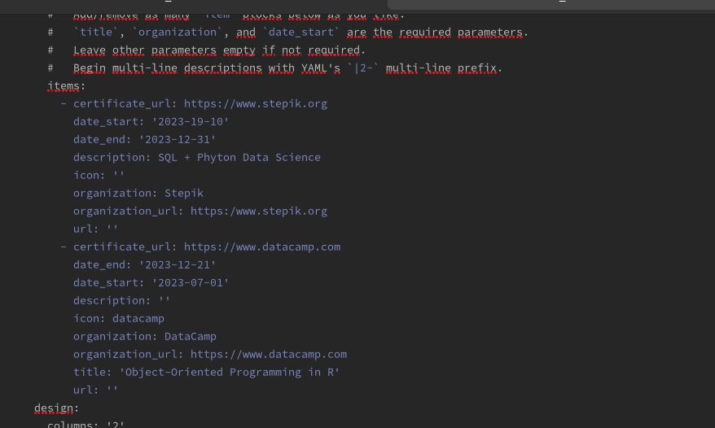

## Выполнение проекта

Чтобы корректно отображались иконки компаний, нужно скачать изображения из интернета в формате svg и перенести в необходимую директорию (рис. 6)

[figure not shown]

Иконки компаний

## Выполнение проекта

Добавила пост на тему по выбору - легкословесные языки разметки, изменив файл index в соответствующей папке (рис. 7)

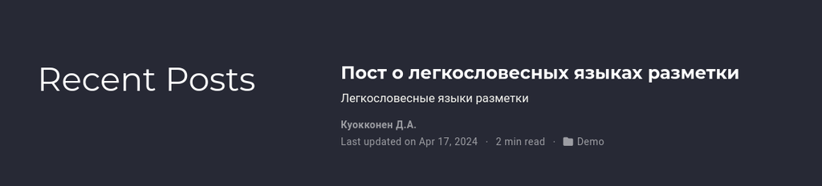

Добавление поста на тему по выбору

## Выполнение проекта

Добавил пост по прошедшим 5 дням в той же папке (рис. 8)

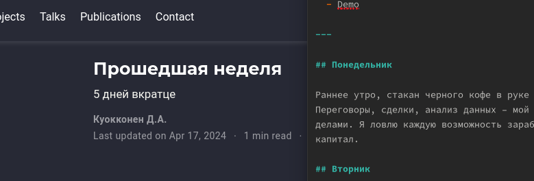

Добавление поста по прошедшей неделе

## Выполнение проекта

Закрываю локальный сервер с помощью клавиш Ctrl+C и собираю сайт с изменениями, введя команду ~/bin/hugo без аргументов (рис. 9)

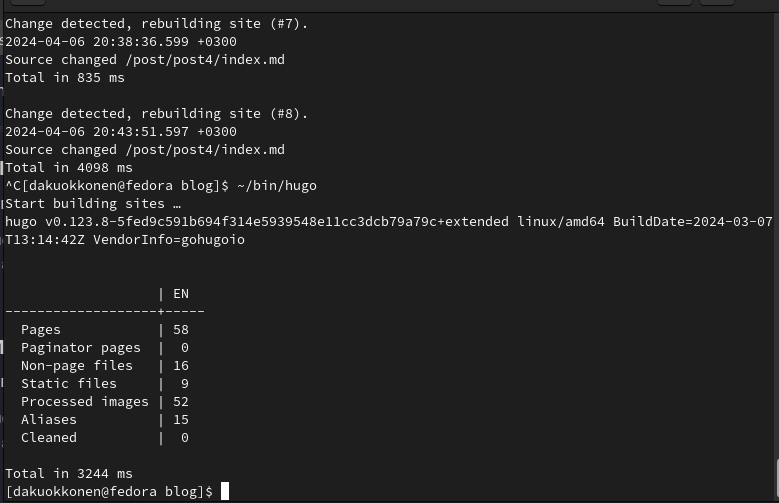

Закрытие локального сервера

## Выполнение проекта

Отправляю изменения на GitHub (рис. 10)

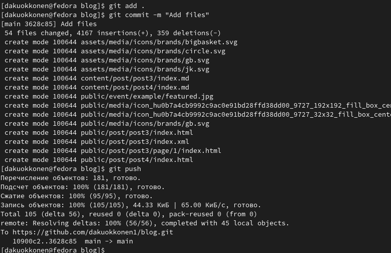

Отправка изменений на Git